# Patterns in Interaction Terms & Trajectory Analysis

Dean Adams (dcadams@iastate.edu)

2021-03-11

### **Motivation**

As we discussed in lecture, interactions between main effects in a linear model describe context-dependent patterns in one’s data. For instance, in the model: `Y~cov+group+cov:group`, a significant `cov:group` term implies that the relationship between Y and the covariate differs in some way among the groups. Such patterns are very common in biology and in fact describe patterns of considerable interest. However, with multivariate data, simply identifying a significant interaction in a linear model is only the first step towards understanding.

Once a significant interaction has been identified, one must then dig deeper to understand its meaning. Below is an example for a factrial MANOVA.

#### **1: Multivariate Pairwise Comparisons**

As seen in previous weeks, one can perform pairwise comparisons among groups via RRPP. The approach is based on distances between group means.

```r
library(RRPP)
data(Pupfish)
Pupfish$Group <- interaction(Pupfish$Sex, Pupfish$Pop)
fit.m <- lm.rrpp(coords ~ Pop * Sex, data = Pupfish, print.progress = FALSE)
anova(fit.m)$table
```

```
##           Df       SS        MS     Rsq      F      Z Pr(>F)
## Pop        1 0.008993 0.0089927 0.15964 16.076 3.9997  0.001 **
## Sex        1 0.015917 0.0159169 0.28255 28.453 4.1103  0.001 **
## Pop:Sex    1 0.003453 0.0034532 0.06130  6.173 3.7015  0.001 **
## Residuals 50 0.027970 0.0005594 0.49651
## Total     53 0.056333
## ---
## Signif. codes:  0 '***' 0.001 '**' 0.01 '*' 0.05 '.' 0.1 ' ' 1
```

Note that the interaction between `pop` and `sex` is significant. This implies that some `pop:sex`combination(s) differ from the others, but not which ones. To identify which groups differ, we need multiple comparison tests.

```r
summary(pairwise(fit.m,groups = Pupfish$Group))
```

```
##
## Pairwise comparisons
##
## Groups: F.Marsh M.Marsh F.Sinkhole M.Sinkhole
##
## RRPP: 1000 permutations
##
## LS means:
## Vectors hidden (use show.vectors = TRUE to view)
##
## Pairwise distances between means, plus statistics
##                                d  UCL (95%)          Z Pr > d
## F.Marsh:M.Marsh       0.04611590 0.04297378  2.3159417  0.007
## F.Marsh:F.Sinkhole    0.03302552 0.03312516  1.6124629  0.055
## F.Marsh:M.Sinkhole    0.03881514 0.04633821 -0.5421145  0.699
## M.Marsh:F.Sinkhole    0.04605211 0.05506197 -0.2523753  0.597
## M.Marsh:M.Sinkhole    0.02802087 0.03343901  0.1854026  0.420
## F.Sinkhole:M.Sinkhole 0.02568508 0.04364031 -2.2111968  0.993
```

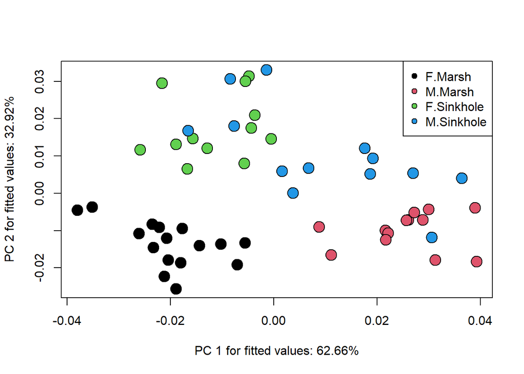

```r
plot(fit.m, type = "PC", pch=21, bg = Pupfish$Group, cex=2)
legend("topright", levels(Pupfish$Group), pch = 21, pt.bg = 1:4)
```

#### **1b: MANCOVA Models: LS-Mean Comparisons**

For MANCOVA models, a covariate is included in the model. Now several comparisons are of interest. First, one can compare groups (LS-means) while accounting for the covariate.

```r
Pupfish$logSize <- log(Pupfish$CS)
fit.slopes <- lm.rrpp(coords ~ logSize * Pop * Sex, data = Pupfish, print.progress = FALSE)
anova(fit.slopes)$table
```

```
##                 Df       SS        MS     Rsq       F      Z Pr(>F)
## logSize          1 0.014019 0.0140193 0.24886 29.2078 5.0041  0.001 **
## Pop              1 0.010247 0.0102472 0.18190 21.3491 4.7949  0.001 **
## Sex              1 0.005028 0.0050284 0.08926 10.4763 4.5388  0.001 **
## logSize:Pop      1 0.001653 0.0016528 0.02934  3.4434 2.6259  0.004 **
## logSize:Sex      1 0.001450 0.0014498 0.02574  3.0206 2.2721  0.014 *
## Pop:Sex          1 0.001370 0.0013696 0.02431  2.8534 2.2866  0.010 *
## logSize:Pop:Sex  1 0.000486 0.0004865 0.00864  1.0135 0.3337  0.382
## Residuals       46 0.022079 0.0004800 0.39194
## Total           53 0.056333
## ---
## Signif. codes:  0 '***' 0.001 '**' 0.01 '*' 0.05 '.' 0.1 ' ' 1
```

```r
PWS.gp <- pairwise(fit.slopes, groups = Pupfish$Group)
summary(PWS.gp)
```

```
##
## Pairwise comparisons
##
## Groups: F.Marsh M.Marsh F.Sinkhole M.Sinkhole
##
## RRPP: 1000 permutations
##
## LS means:
## Vectors hidden (use show.vectors = TRUE to view)
##
## Pairwise distances between means, plus statistics
##                                d  UCL (95%)            Z Pr > d
## F.Marsh:M.Marsh       0.03750941 0.04531287  0.002246837  0.503
## F.Marsh:F.Sinkhole    0.03719039 0.04374134 -0.221789776  0.590
## F.Marsh:M.Sinkhole    0.03808475 0.04277692 -0.495662717  0.696
## M.Marsh:F.Sinkhole    0.04409490 0.05311727  0.352149542  0.354
## M.Marsh:M.Sinkhole    0.02842126 0.03729487  0.008211561  0.482
## F.Sinkhole:M.Sinkhole 0.02477046 0.03228372 -0.122666544  0.550
```

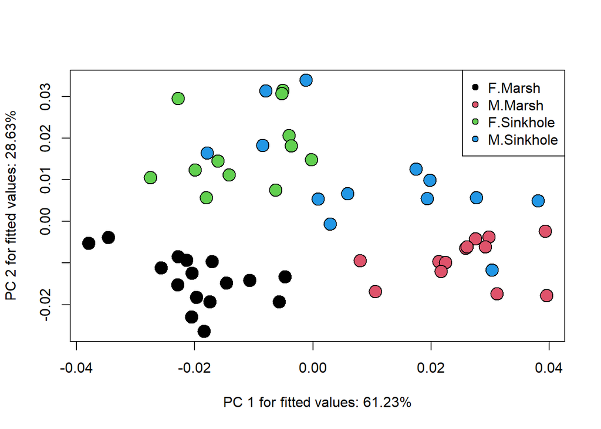

```r
plot(fit.slopes, type = "PC", pch=21, bg = Pupfish$Group, cex=2)
legend("topright", levels(Pupfish$Group), pch = 21, pt.bg = 1:4)
```

Note that the distances between pairs of group means are not the same as in the first example, because the covariate has been taken into account in the analysis.

#### **1c: MANCOVA Models: Slope Comparisons**

Additionally, one can compare the slopes among groups.

```r
PWS <- pairwise(fit.slopes, groups = Pupfish$Group, covariate = Pupfish$logSize)
summary(PWS)
```

```
##
## Pairwise comparisons
##
## Groups: F.Marsh M.Marsh F.Sinkhole M.Sinkhole
##
## RRPP: 1000 permutations
##
## Slopes (vectors of variate change per one unit of covariate
##         change, by group):
## Vectors hidden (use show.vectors = TRUE to view)
##
## Pairwise distances between slope vector
##             (end-points), plus statistics
##                                d UCL (95%)          Z Pr > d
## F.Marsh:M.Marsh       0.08279940 0.2033602 -1.9636763  0.977
## F.Marsh:F.Sinkhole    0.07848121 0.1846494 -1.8491879  0.970
## F.Marsh:M.Sinkhole    0.12322729 0.2581796 -1.4771494  0.928
## M.Marsh:F.Sinkhole    0.06418279 0.1293582 -2.3787828  0.992
## M.Marsh:M.Sinkhole    0.10863856 0.1498666  0.4143532  0.348
## F.Sinkhole:M.Sinkhole 0.11706696 0.1566431  0.3505166  0.377
```

```r
summary(PWS, test.type = "VC", angle.type = "deg")
```

```
##
## Pairwise comparisons
##
## Groups: F.Marsh M.Marsh F.Sinkhole M.Sinkhole
##
## RRPP: 1000 permutations
##
## Slopes (vectors of variate change per one unit of covariate
##         change, by group):
## Vectors hidden (use show.vectors = TRUE to view)
##
## Pairwise statistics based on slopes vector correlations (r)
##           and angles, acos(r)
## The null hypothesis is that r = 1 (parallel vectors).
## This null hypothesis is better treated as the angle
##           between vectors = 0
##                               r    angle UCL (95%)          Z Pr > angle
## F.Marsh:M.Marsh       0.6139591 52.12367  95.40553 -1.0051685      0.844
## F.Marsh:F.Sinkhole    0.6318267 50.81498  88.71850 -0.8268874      0.782
## F.Marsh:M.Sinkhole    0.4461018 63.50614 116.45215 -1.3459215      0.904
## M.Marsh:F.Sinkhole    0.7175129 44.15048  77.31288 -1.4269023      0.926
## M.Marsh:M.Sinkhole    0.5629975 55.73665  74.08894  0.5136053      0.316
## F.Sinkhole:M.Sinkhole 0.4627734 62.43378  81.64708  0.4261192      0.342
```

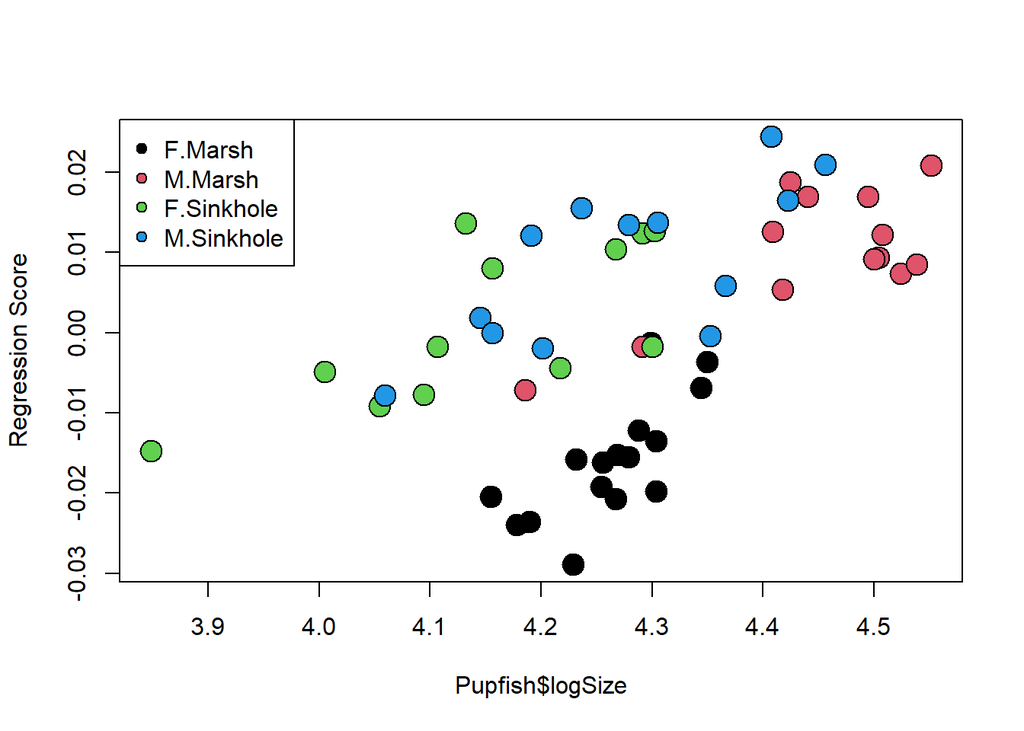

```r
plot(fit.slopes, type = "regression", reg.type = "RegScore", pch=21, bg = Pupfish$Group, predictor = Pupfish$logSize, cex=2)
legend("topleft", levels(Pupfish$Group), pch = 21, pt.bg = 1:4)
```

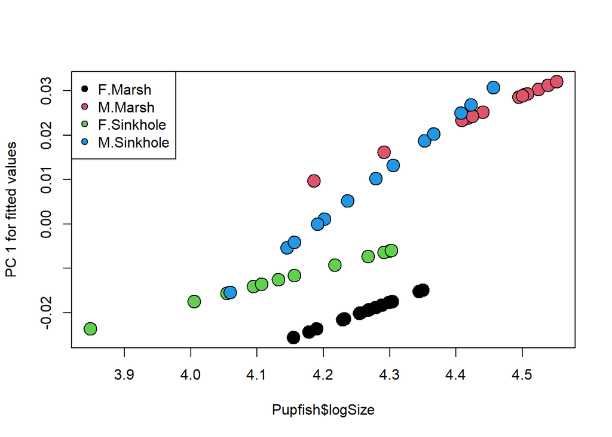

```r
plot(fit.slopes, type = "regression", reg.type = "PredLine", pch=21, bg = Pupfish$Group, predictor = Pupfish$logSize, cex=2)
legend("topleft", levels(Pupfish$Group), pch = 21, pt.bg = 1:4)
```

Note that the above provides comparisons allow for the length of the regression vector, as well as a test of the angular direction of the regressions in the multivariate trait space.

Together, these procedures provide considerable flexibility in evaluating patterns that comprise significant interaction terms.

#### **2: Trajectory Analysis**

In this analysis, each level of factor 1 (e.g., species) is a trajectory in the multivariate space, which is formed by its corresponding least squares means ($\overline{Y}$) for the levels of factor B (e.g., site). This effectively ‘links’ the data from factor B within its level of factor A, forming the trajectory.

These trajectories then have higher-order attributes in the multivariate space, and these may be statistically compared. First, they have a magnitude (length), and second, they have a direction. For trajectories with 3 or more levels they also have a shape.

Let’s show an example for the data above. Here, our trajectories represent the degree of sexual dimorphism in each pupfish population.

```r
fit <- lm.rrpp(coords ~ Pop * Sex, data = Pupfish, iter = 999,
               print.progress = FALSE)
TA <- trajectory.analysis(fit, groups = Pupfish$Pop,
                          traj.pts = Pupfish$Sex, print.progress = FALSE)

# Magnitude difference (absolute difference between path distances)
summary(TA, attribute = "MD")
```

```
##
## Trajectory analysis
##
## 1000 permutations.
##
## Points projected onto trajectory PCs
##
## Trajectories:
## Trajectories hidden (use show.trajectories = TRUE to view)
##
## Observed path distances by group
##
##      Marsh   Sinkhole
## 0.04611590 0.02568508
##
## Pairwise absolute differences in path distances, plus statistics
##                         d UCL (95%)        Z Pr > d
## Marsh:Sinkhole 0.02043082  0.012731 2.671911  0.001
```

```r
# Correlations (angles) between trajectories
summary(TA, attribute = "TC", angle.type = "deg")
```

```
##
## Trajectory analysis
##
## 1000 permutations.
##
## Points projected onto trajectory PCs
##
## Trajectories:
## Trajectories hidden (use show.trajectories = TRUE to view)
##
## Pairwise correlations between trajectories, plus statistics
##                        r    angle UCL (95%)       Z Pr > angle
## Marsh:Sinkhole 0.7393716 42.32209  24.12074 3.54113      0.001
```

Notice that in this example, there is evidence for differences in trajectory length, as well as trajectory direction. This means that there is greater sexual dimorphism in one population as compared to another, and also in the manner in which sexual dimorphism occurs.

Looking at these graphically we see the pattern:

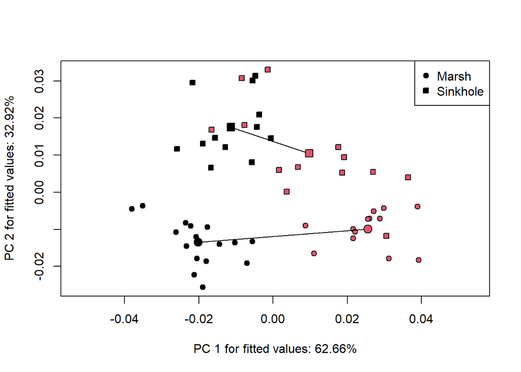

```r
TP <- plot(TA, pch = as.numeric(Pupfish$Pop) + 20, bg = as.numeric(Pupfish$Sex),
           cex = 1, col = "black")
add.trajectories(TP, traj.pch = c(21, 22), start.bg = 1, end.bg = 2)
legend("topright", levels(Pupfish$Pop), pch =  c(21, 22), pt.bg = 1)
```

#### **2a: Multiple Trajectories & Multiple Levels**

The approach works unaltered for more complicated datasets.

```r
data(motionpaths)
fit <- lm.rrpp(trajectories ~ groups, data = motionpaths, iter = 999,
               print.progress = FALSE)
TA <- trajectory.analysis(fit, groups = motionpaths$groups, traj.pts = 5,
                          print.progress = FALSE)

# Magnitude difference (absolute difference between path distances)
summary(TA, attribute = "MD")
```

```
##
## Trajectory analysis
##
## 1000 permutations.
##
##
## Trajectories:
## Trajectories hidden (use show.trajectories = TRUE to view)
##
## Observed path distances by group
##
##         1         2         3         4
## 10.144421  6.557011 10.949722 10.097348
##
## Pairwise absolute differences in path distances, plus statistics
##              d UCL (95%)          Z Pr > d
## 1:2 3.58741011  1.317461  3.8913405  0.001
## 1:3 0.80530081  1.247854  0.7320629  0.250
## 1:4 0.04707265  1.284309 -1.6674019  0.950
## 2:3 4.39271092  1.262817  4.5955836  0.001
## 2:4 3.54033746  1.333765  3.8250970  0.001
## 3:4 0.85237346  1.251712  0.8703440  0.213
```

```r
# Correlations (angles) between trajectories
summary(TA, attribute = "TC", angle.type = "deg")
```

```
##
## Trajectory analysis
##
## 1000 permutations.
##
##
## Trajectories:
## Trajectories hidden (use show.trajectories = TRUE to view)
##
## Pairwise correlations between trajectories, plus statistics
##             r     angle UCL (95%)          Z Pr > angle
## 1:2 0.9989147  2.669593  20.70022 -0.8792581      0.808
## 1:3 0.6122502 52.247611  22.06576  3.5215617      0.001
## 1:4 0.9996899  1.426827  20.81629 -1.3327426      0.901
## 2:3 0.6484120 49.578018  21.87022  3.3651369      0.001
## 2:4 0.9974452  4.096420  21.08371 -0.5446100      0.700
## 3:4 0.5923727 53.674438  21.14215  3.5973574      0.001
```

```r
# Shape differences between trajectories
summary(TA, attribute = "SD")
```

```
##
## Trajectory analysis
##
## 1000 permutations.
##
##
## Trajectories:
## Trajectories hidden (use show.trajectories = TRUE to view)
##
## Pairwise trajectory shape differences, plus statistics
##              d UCL (95%)           Z Pr > d
## 1:2 0.10279471 0.1855284 -0.15347678  0.551
## 1:3 0.10686382 0.1879151 -0.04044511  0.512
## 1:4 0.28213028 0.1881749  2.98789933  0.002
## 2:3 0.07843294 0.1862637 -0.91031401  0.814
## 2:4 0.36491114 0.1877718  3.94123541  0.001
## 3:4 0.35086211 0.1859428  4.01741549  0.001
```

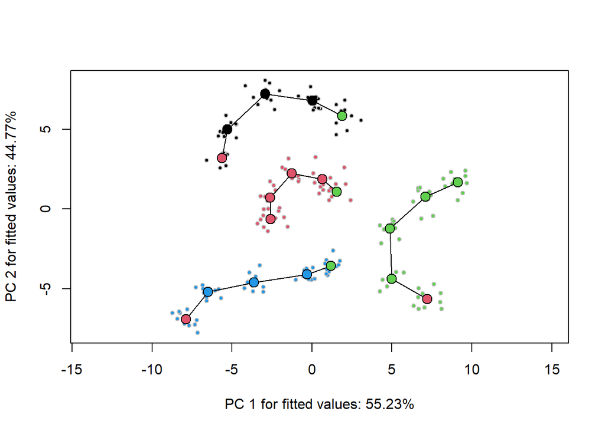

```r
TP <- plot(TA, pch = 21, bg = as.numeric(motionpaths$groups),
           cex = 0.7, col = "gray")
add.trajectories(TP, traj.pch = 21, traj.bg = 1:4)
```